[**Imtiaj.**](https://imtiajiqbalmahfuj.github.io/index.html#top)

# Spatiotemporal Characterization & Non-Stationary Air Quality Modeling

### A cloud-native GeoAI pipeline mapping atmospheric pollutants and thermal dynamics across Lubbock, Texas.

> *Bridging the gap between predictive accuracy and physical interpretability in environmental spatial data science.* 🌍

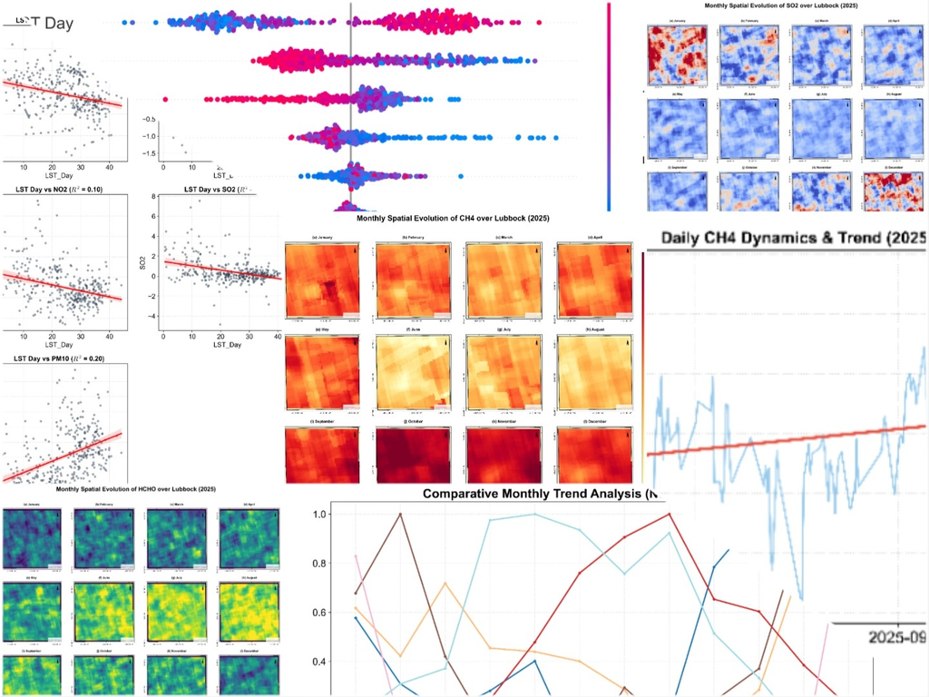

> **Author:** Imtiaj Iqbal Mahfuj

## 📝 Overview

This project explores **spatial patterns**, integrates **remote sensing datasets**, and applies **geospatial Python tools** to visualize and analyze multi-pollutant interactions and surface thermal dynamics over Lubbock, Texas. It aims to uncover key insights that support data-driven decision-making for semi-arid urban-agricultural interfaces that face severe atmospheric stress from episodic dust storms, agricultural particulate emissions, and extreme thermal variances.

The primary objective is to establish a reproducible, cloud-based analytical architecture that quantifies multi-pollutant distributions, detects intra-annual monotonic trends, and maps the spatial non-stationarity of air quality drivers. Rather than relying on traditional ground-based monitoring networks that fail to capture high-resolution spatial gradients, this research synthesizes a multi-sensor satellite array into a single analytical pipeline.

Ultimately, this workflow extracts daily and monthly data to generate continuous Geographically Weighted Regression (GWR) zonal surfaces, training algorithms to isolate casualty within complex environments. It automatically exports publication-grade maps and datasets, providing empirical blueprints for targeted environmental interventions.

## 🛠️ Tools & Technologies

## ⚙️ Methodology

[output not shown]

## Codes 👇

```python
# SPATIOTEMPORAL DYNAMICS & NON-STATIONARY AIR QUALITY MODELING
# Study Area: Lubbock County, Texas, USA
# Analytical Pillars: Sameh et al. (2026), Rahman et al. (2025), Alvarez et al. (2025)
# ==============================================================================

import os
import math
import copy
import warnings
import numpy as np
import pandas as pd
import geopandas as gpd
import matplotlib.pyplot as plt
import matplotlib.colors as mcolors
import matplotlib.patches as mpatches
from matplotlib.ticker import MaxNLocator, FuncFormatter
from matplotlib_scalebar.scalebar import ScaleBar
import seaborn as sns
import scipy.stats as stats
from scipy.interpolate import griddata

# Geospatial & Earth Engine Libraries
import ee
import geemap
from shapely.geometry import Point

# Machine Learning & SHAP Analytics (Alvarez et al., 2025)
from sklearn.preprocessing import StandardScaler
from sklearn.decomposition import PCA
from sklearn.svm import SVR
from sklearn.linear_model import Ridge
from sklearn.ensemble import RandomForestRegressor, GradientBoostingRegressor
from sklearn.neighbors import KNeighborsRegressor
from sklearn.model_selection import train_test_split
from sklearn.metrics import r2_score, mean_squared_error
import shap

warnings.filterwarnings('ignore')
```

```python
# 1. INITIALIZATION & PUBLICATION STYLING (IEEE/Elsevier Standard)
# ------------------------------------------------------------------------------
try:
    ee.Initialize()
except Exception:
    ee.Authenticate()
    ee.Initialize()

OUTPUT_DIR = "Lubbock_AQ_Outputs"
os.makedirs(OUTPUT_DIR, exist_ok=True)

# Strict Academic Typography and Resolution Settings
plt.rcParams.update({
    'font.family': 'sans-serif',
    'font.sans-serif': ['Arial', 'Helvetica', 'DejaVu Sans'],
    'text.usetex': False,
    'mathtext.fontset': 'cm',
    'font.size': 13,
    'axes.titlesize': 14,
    'axes.labelsize': 14,
    'xtick.labelsize': 14,
    'ytick.labelsize': 14,
    'legend.fontsize': 12,
    'figure.dpi': 500,
    'savefig.dpi': 500,
    'savefig.bbox': 'tight'
})

def apply_custom_map_style(ax, reference_gdf, title="", tight=False, is_factor_grid=False):
    """Applies high-fidelity mapping styles, scalebars, and orientation markers."""
    if is_factor_grid:
        ax.tick_params(top=True, bottom=True, left=True, right=True,
                       direction='in', labeltop=False, labelbottom=True,
                       labelleft=True, labelright=False, pad=4, labelsize=7)
        ax.xaxis.set_major_locator(MaxNLocator(nbins=3, prune='both'))
        ax.yaxis.set_major_locator(MaxNLocator(nbins=3, prune='both'))
        ax.set_title(title, pad=12, fontweight='bold', fontsize=12)
    else:
        ax.tick_params(top=True, bottom=True, left=True, right=True,
                       direction='in', labeltop=True, labelbottom=True,
                       labelleft=True, labelright=True, pad=5, labelsize=10)
        ax.xaxis.set_major_locator(MaxNLocator(nbins=4, prune='both'))
        ax.yaxis.set_major_locator(MaxNLocator(nbins=4, prune='both'))
        ax.set_title(title, pad=20, fontweight='bold', fontsize=16)

    ax.tick_params(axis='y', labelrotation=90)
    ax.xaxis.set_major_formatter(FuncFormatter(lambda x, _: f"{x:.2f}° W"))
    ax.yaxis.set_major_formatter(FuncFormatter(lambda y, _: f"{y:.2f}° N"))

    # Add Scale Bar and North Arrow Elements
    # FIXED EPSG: Lubbock Texas is UTM Zone 14N (EPSG:32614), ensuring accurate scalebar geometry
    projected_centroid = reference_gdf.to_crs(epsg=32614).geometry.centroid.to_crs(epsg=4326)
    center_lat = projected_centroid.y.iloc[0]
    deg_points = gpd.GeoSeries([Point(-102.0, center_lat), Point(-101.0, center_lat)], crs="EPSG:4326").to_crs(epsg=32614)
    meters_per_degree = deg_points.iloc[0].distance(deg_points.iloc[1])

    scalebar = ScaleBar(dx=meters_per_degree, units="m", location="lower right",
                        box_alpha=0.7, color='white', font_properties={'size': 7})
    ax.add_artist(scalebar)

    ax.annotate('N', xy=(0.93, 0.93), xytext=(0.93, 0.87),
                arrowprops=dict(facecolor='black', width=1.0, headwidth=4, shrink=0.05),
                ha='center', va='center', fontweight='bold', fontsize=9, xycoords='axes fraction')

    # Handle Frame Boundaries
    bounds = reference_gdf.total_bounds
    padding = 0.006 if tight else 0.016
    ax.set_xlim(bounds[0] - padding, bounds[2] + padding)
    ax.set_ylim(bounds[1] - padding, bounds[3] + padding)
```

```python
# 2. STUDY AREA & GEOMETRIC EXTRACTION
# ------------------------------------------------------------------------------
print("⌛ Defining Administrative Boundaries for Lubbock, Texas...")
counties = ee.FeatureCollection("TIGER/2018/Counties")
roi_ee = counties.filter(ee.Filter.And(
    ee.Filter.eq('STATEFP', '48'),
    ee.Filter.eq('NAME', 'Lubbock')
))
roi = roi_ee.geometry()
```

```python
# Extract Census Blocks to view structural overlays on Maps
census_blocks = ee.FeatureCollection("TIGER/2010/Blocks").filterBounds(roi)
blocks_gdf = geemap.ee_to_gdf(census_blocks)

roi_gdf = geemap.ee_to_gdf(roi_ee)
bounds = roi_gdf.total_bounds
lon_min, lat_min, lon_max, lat_max = bounds

YEAR = 2025
START_DATE = f"{YEAR}-01-01"
END_DATE = f"{YEAR+1}-01-01"
MONTHS = ['January', 'February', 'March', 'April', 'May', 'June',
          'July', 'August', 'September', 'October', 'November', 'December']
```

```python
# 3. SATELLITE DATA CATALOG HARMONIZATION
# References: Sameh et al. (2026); Rahman et al. (2025)
# ------------------------------------------------------------------------------
# Filtered strictly to requested parameters (Removed CO and O3)
datasets_meta = {
    'CH4': {'col': 'COPERNICUS/S5P/OFFL/L3_CH4', 'band': 'CH4_column_volume_mixing_ratio_dry_air', 'scale': 1, 'unit': 'ppb', 'cmap': 'YlOrRd'},
    'UVAI': {'col': 'COPERNICUS/S5P/OFFL/L3_AER_AI', 'band': 'absorbing_aerosol_index', 'scale': 1, 'unit': 'Index', 'cmap': 'magma'},
    'HCHO': {'col': 'COPERNICUS/S5P/OFFL/L3_HCHO', 'band': 'tropospheric_HCHO_column_number_density', 'scale': 1e4, 'unit': '1e-4 mol/m²', 'cmap': 'viridis'},
    'NO2': {'col': 'COPERNICUS/S5P/OFFL/L3_NO2', 'band': 'tropospheric_NO2_column_number_density', 'scale': 1e4, 'unit': '1e-4 mol/m²', 'cmap': 'Spectral_r'},
    'SO2': {'col': 'COPERNICUS/S5P/OFFL/L3_SO2', 'band': 'SO2_column_number_density', 'scale': 1e4, 'unit': '1e-4 mol/m²', 'cmap': 'coolwarm'},
}

lst_col = ee.ImageCollection('MODIS/061/MOD11A1').filterBounds(roi).filterDate(START_DATE, END_DATE)
aod_col = ee.ImageCollection('MODIS/061/MCD19A2_GRANULES').filterBounds(roi).filterDate(START_DATE, END_DATE).select('Optical_Depth_055')

# datasets_meta = {
#     'CH4': {'col': 'COPERNICUS/S5P/OFFL/L3_CH4', 'band': 'CH4_column_volume_mixing_ratio_dry_air', 'scale': 1, 'unit': 'ppb', 'cmap': 'YlOrRd'},
#     'UVAI': {'col': 'COPERNICUS/S5P/OFFL/L3_AER_AI', 'band': 'absorbing_aerosol_index', 'scale': 1, 'unit': 'Index', 'cmap': 'magma'},
#     'HCHO': {'col': 'COPERNICUS/S5P/OFFL/L3_HCHO', 'band': 'tropospheric_HCHO_column_number_density', 'scale': 1e4, 'unit': '1e-4 mol/m²', 'cmap': 'viridis'},
#     'O3': {'col': 'COPERNICUS/S5P/OFFL/L3_O3', 'band': 'O3_column_number_density', 'scale': 1, 'unit': 'mol/m²', 'cmap': 'plasma'},
#     'CO': {'col': 'COPERNICUS/S5P/OFFL/L3_CO', 'band': 'CO_column_number_density', 'scale': 1, 'unit': 'mol/m²', 'cmap': 'inferno'},
#     'NO2': {'col': 'COPERNICUS/S5P/OFFL/L3_NO2', 'band': 'tropospheric_NO2_column_number_density', 'scale': 1e4, 'unit': '1e-4 mol/m²', 'cmap': 'Spectral_r'},
#     'SO2': {'col': 'COPERNICUS/S5P/OFFL/L3_SO2', 'band': 'SO2_column_number_density', 'scale': 1e4, 'unit': '1e-4 mol/m²', 'cmap': 'coolwarm'},
# }

# # LST, AOD(PM25/PM10), & ERA5 Meteorology
# lst_col = ee.ImageCollection('MODIS/061/MOD11A1').filterBounds(roi).filterDate(START_DATE, END_DATE)
# aod_col = ee.ImageCollection('MODIS/061/MCD19A2_GRANULES').filterBounds(roi).filterDate(START_DATE, END_DATE).select('Optical_Depth_055')
# era5_col = ee.ImageCollection('ECMWF/ERA5_LAND/DAILY_AGGR').filterBounds(roi).filterDate(START_DATE, END_DATE)


def get_pm_models(aod_img):
    """Empirical calibration of AOD to PM2.5 and PM10 (Sameh et al., 2026; Eqs. 1 & 2)."""
    aod_scaled = aod_img.multiply(0.001)
    pm25 = aod_scaled.multiply(165.69).add(8.7597).rename('PM25')
    pm10 = aod_scaled.multiply(195.70).add(14.500).rename('PM10')
    return pm25.addBands(pm10)

# Initialize Interactive Geemap
Map = geemap.Map(center=[33.5779, -101.8552], zoom=10)
Map.add_basemap('SATELLITE')
Map.addLayer(roi_ee, {'color': 'red'}, 'Lubbock Boundary', False, 0.5)
```

```python
# 4. TEMPORAL EXTRACTION & MANN-KENDALL TRENDS
# ------------------------------------------------------------------------------
print("⌛ Compiling Daily and Monthly Regional Aggregates...")

def extract_daily_data():
    """Maps across a 365-day sequence natively in Earth Engine to bypass memory limits."""
    def extract_day(d_offset):
        d_start = ee.Date(START_DATE).advance(d_offset, 'day')
        d_end = d_start.advance(1, 'day')
        feat = ee.Feature(None, {'Date': d_start.format('YYYY-MM-dd')})

        # MODIS LST (Needed for Correlational & Predictor Analytics)
        lst_day = lst_col.filterDate(d_start, d_end).mean().select('LST_Day_1km').multiply(0.02).subtract(273.15).rename('LST_Day_1km')
        dict_lst_d = lst_day.reduceRegion(ee.Reducer.mean(), roi, 1000)
        feat = feat.set('LST_Day', dict_lst_d.combine(ee.Dictionary({'LST_Day_1km': -9999}), False).get('LST_Day_1km'))

        # PM25 & PM10
        pm = get_pm_models(aod_col.filterDate(d_start, d_end).mean())
        dict_pm25 = pm.select('PM25').reduceRegion(ee.Reducer.mean(), roi, 1000)
        feat = feat.set('PM25', dict_pm25.combine(ee.Dictionary({'PM25': -9999}), False).get('PM25'))

        dict_pm10 = pm.select('PM10').reduceRegion(ee.Reducer.mean(), roi, 1000)
        feat = feat.set('PM10', dict_pm10.combine(ee.Dictionary({'PM10': -9999}), False).get('PM10'))

        # Trace Gases (Using combined dict to safely bypass masked swaths)
        for k, m in datasets_meta.items():
            img = ee.ImageCollection(m['col']).filterBounds(roi).filterDate(d_start, d_end).select(m['band']).mean()
            dict_gas = img.reduceRegion(ee.Reducer.mean(), roi, 1113.2)
            feat = feat.set(k, dict_gas.combine(ee.Dictionary({m['band']: -9999}), False).get(m['band']))

        return feat

    days = ee.List.sequence(0, 364)
    fc = ee.FeatureCollection(days.map(extract_day))

    # Retrieve properties and parse to DataFrame, strictly resolving -9999 to NaN
    df = geemap.ee_to_df(fc).dropna(subset=['Date']).replace(-9999, np.nan)
    df['Date'] = pd.to_datetime(df['Date'])
    df = df.set_index('Date').sort_index().astype(float)

    for k, m in datasets_meta.items():
        if k in df.columns:
            df[k] = df[k] * m['scale']

    return df.interpolate(method='linear', limit_direction='both')

df_daily = extract_daily_data()
df_monthly = df_daily.resample('ME').mean()
df_monthly.index = MONTHS

df_daily.to_excel(os.path.join(OUTPUT_DIR, 'Table1_Daily_Data_2025.xlsx'))
df_monthly.to_excel(os.path.join(OUTPUT_DIR, 'Table2_Monthly_Data_2025.xlsx'))
```

```python
# Core map/plot variables strictly constrained to user request
plot_vars = ['CH4', 'UVAI', 'HCHO', 'NO2', 'SO2', 'PM25', 'PM10']
#variables = ['CH4', 'UVAI', 'HCHO', 'O3', 'CO', 'NO2', 'SO2', 'LST_Day', 'LST_Night', 'PM25', 'PM10', 'Temperature', 'Surface_Pressure']

# --- Plotting Daily vs Monthly Trends ---
print("⌛ Generating Temporal Graphs (Daily with Trend & Monthly)...")
for var in plot_vars:
    fig, axes = plt.subplots(1, 2, figsize=(18, 6))
    var_label = 'PM2.5' if var == 'PM25' else var

    # Daily + Trend
    ax1 = axes[0]
    ax1.plot(df_daily.index, df_daily[var], color='#3498db', alpha=0.5, label='Daily Mean')
    x_num = np.arange(len(df_daily))
    mask = ~np.isnan(df_daily[var].values)
    if mask.sum() > 2:
        slope, intercept, r_val, p_val, std_err = stats.linregress(x_num[mask], df_daily[var].values[mask])
        ax1.plot(df_daily.index, intercept + slope * x_num, color='#e74c3c', lw=2.5, label=f'Trend ($R^2$={r_val**2:.2f})')

    ax1.set_title(f'Daily {var_label} Dynamics & Trend ({YEAR})', weight='bold')
    ax1.set_ylabel(var_label, weight='bold')
    ax1.grid(linestyle=':', alpha=0.6)
    ax1.legend()

    # Monthly
    ax2 = axes[1]
    ax2.plot(MONTHS, df_monthly[var], color='#2ecc71', marker='o', lw=2.5, markersize=8)
    ax2.set_title(f'Monthly Averaged {var_label} ({YEAR})', weight='bold')
    ax2.tick_params(axis='x', rotation=45)
    ax2.grid(linestyle=':', alpha=0.6)

    plt.tight_layout()
    plt.savefig(os.path.join(OUTPUT_DIR, f'Graph_Trend_{var}.png'))
    plt.show()
```

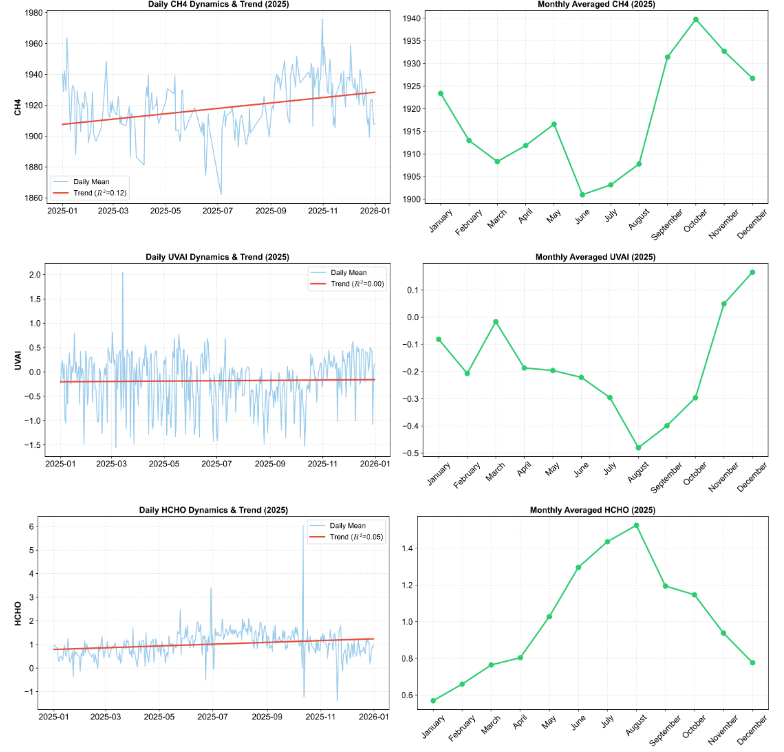

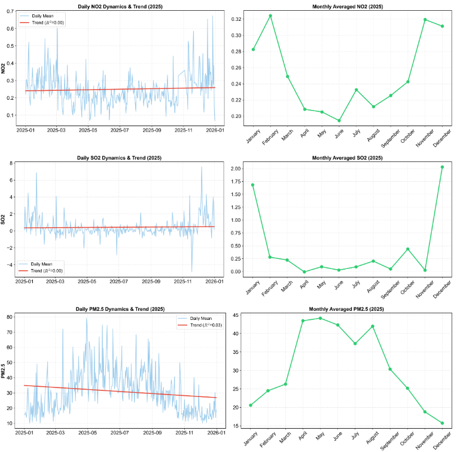

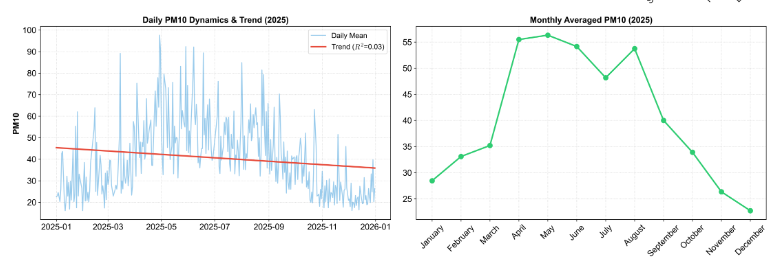

```python
# Combined Normalized Line Graph
fig, ax = plt.subplots(figsize=(14, 7))
df_norm = (df_monthly - df_monthly.min()) / (df_monthly.max() - df_monthly.min())
colors = plt.cm.tab20(np.linspace(0, 1, len(variables)))

for i, var in enumerate(plot_vars):
    ax.plot(MONTHS, df_norm[var], label=var, color=colors[i], marker='.', lw=2)

ax.set_title(f'Comparative Monthly Trend Analysis (Normalized 0-1) - {YEAR}', weight='bold', fontsize=18)
ax.tick_params(axis='x', rotation=45)
ax.legend(bbox_to_anchor=(1.02, 1), loc='upper left', ncol=1)
ax.grid(linestyle=':', alpha=0.6)
plt.savefig(os.path.join(OUTPUT_DIR, 'Graph_Combined_Comparison.png'), bbox_inches='tight')
plt.show()
```

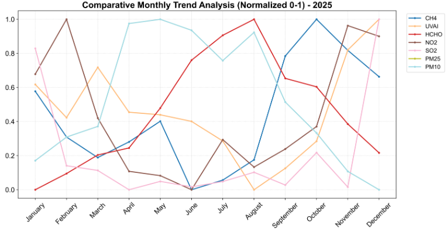

```python
# --- Mann-Kendall Trend Analysis ---
print("⌛ Computing Mann-Kendall Monotonic Trends...")
def mann_kendall_tau(data):
    n = len(data)
    s = sum(np.sign(data[j] - data[k]) for k in range(n - 1) for j in range(k + 1, n))
    tau, p_val = stats.kendalltau(np.arange(n), data)
    return tau, p_val

mk_data = []
for col in plot_vars:
    tau, pval = mann_kendall_tau(df_monthly[col].values)
    trend = 'Increasing' if tau > 0 and pval < 0.05 else ('Decreasing' if tau < 0 and pval < 0.05 else 'No Trend')
    mk_data.append({'Parameter': col.replace('PM25', 'PM2.5'), 'Kendall_Tau': tau, 'p_Value': pval, 'Trend': trend})

df_mk = pd.DataFrame(mk_data)
df_mk.to_excel(os.path.join(OUTPUT_DIR, 'Table3_Mann_Kendall_Trends.xlsx'), index=False)

fig, ax = plt.subplots(figsize=(10, 6))
colors = ['#d62728' if t == 'Increasing' else ('#1f77b4' if t == 'Decreasing' else '#bdc3c7') for t in df_mk['Trend']]
ax.barh(df_mk['Parameter'], df_mk['Kendall_Tau'], color=colors, edgecolor='black', height=0.6)
ax.axvline(0, color='black', linewidth=1.2, linestyle='-')
ax.set_xlabel("Kendall's Tau", weight='bold')
ax.set_title(f"Mann-Kendall Trend Trajectories for Lubbock ({YEAR})", weight='bold', pad=15)
ax.grid(axis='x', linestyle=':', alpha=0.7)
legend_elements = [mpatches.Patch(color='#d62728', label='Significant Increase'),
                   mpatches.Patch(color='#1f77b4', label='Significant Decrease'),
                   mpatches.Patch(color='#bdc3c7', label='No Significant Trend')]
ax.legend(handles=legend_elements, loc='upper right')
plt.savefig(os.path.join(OUTPUT_DIR, 'Fig1_Mann_Kendall_Trends.png'))
plt.show()
```

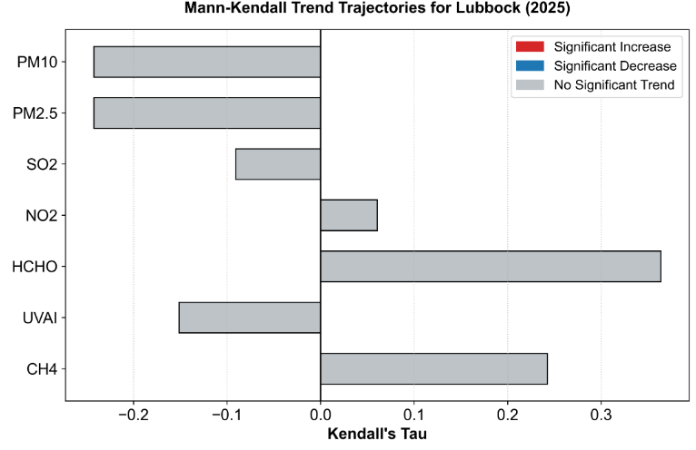

```python
# 5. HIGH-RESOLUTION 12-MONTH SPATIAL GRIDS & MEAN ANNUAL MAPS
# ------------------------------------------------------------------------------
print("⌛ Rendering 12-Month Spatial Grids and Mean Annual Maps for selected parameters...")

def process_and_export_maps(var_key):
    arrays = []

    if var_key in datasets_meta:
        meta = datasets_meta[var_key]
        cmap_name, scale_res = meta['cmap'], 1113.2
    elif 'PM' in var_key:
        cmap_name, scale_res = 'YlOrRd', 1000

    for m in range(1, 13):
        m_start = ee.Date.fromYMD(YEAR, m, 1)
        m_end = m_start.advance(1, 'month')

        if var_key in datasets_meta:
            img = ee.ImageCollection(meta['col']).filterBounds(roi).filterDate(m_start, m_end).select(meta['band']).mean().multiply(meta['scale'])
        elif 'PM' in var_key:
            img = get_pm_models(aod_col.filterDate(m_start, m_end).select('Optical_Depth_055').mean()).select(var_key)

        # Convert to array for matplotlib
        arr = geemap.ee_to_numpy(img.clip(roi).unmask(-9999), region=roi, scale=scale_res)
        arr = np.where(arr < -9000, np.nan, arr)
        arrays.append(arr)

    mean_annual_arr = np.nanmean(np.array(arrays), axis=0)
    all_vals = np.concatenate([a[~np.isnan(a)] for a in arrays if a[~np.isnan(a)].size > 0])
    if len(all_vals) == 0: return

    # Establish scaling boundaries. Manual override for CH4 to prevent extreme color washouts.
    if var_key == 'CH4':
        vmin, vmax = 1890, 1940  # Tightened range to reveal local CH4 spatial contrast
    else:
        vmin, vmax = np.nanpercentile(all_vals, 2), np.nanpercentile(all_vals, 98)

    cmap = copy.copy(plt.get_cmap(cmap_name))
    cmap.set_bad(color='white', alpha=0)
    var_label = 'PM2.5' if var_key == 'PM25' else var_key

    # A. 12-Month Grid (Using 'nearest' interpolation to prevent artifact edge-bleeding)
    fig, axes = plt.subplots(3, 4, figsize=(20, 15))
    axes = axes.flatten()
    for i, ax in enumerate(axes):
        im = ax.imshow(arrays[i], cmap=cmap, vmin=vmin, vmax=vmax, extent=[lon_min, lon_max, lat_min, lat_max], interpolation='nearest')
        roi_gdf.boundary.plot(ax=ax, color='black', linewidth=1.5)
        # blocks_gdf.boundary.plot(ax=ax, edgecolor='gray', linewidth=0.3, alpha=0.4)
        apply_custom_map_style(ax, roi_gdf, f"({chr(97+i)}) {MONTHS[i]}", tight=True, is_factor_grid=True)

    cbar_ax = fig.add_axes([0.92, 0.15, 0.02, 0.7])
    fig.colorbar(im, cax=cbar_ax).set_label(f'{var_label}', weight='bold', fontsize=14)
    fig.suptitle(f"Monthly Spatial Evolution of {var_label} over Lubbock ({YEAR})", fontsize=24, fontweight='bold', y=0.96)
    plt.savefig(os.path.join(OUTPUT_DIR, f'Map_12Month_{var_key}.png'))
    plt.show()

    # B. Mean Annual Map
    fig2, ax2 = plt.subplots(figsize=(10, 10))
    im2 = ax2.imshow(mean_annual_arr, cmap=cmap, vmin=vmin, vmax=vmax, extent=[lon_min, lon_max, lat_min, lat_max], interpolation='nearest')
    roi_gdf.boundary.plot(ax=ax2, color='black', linewidth=2.0)
    blocks_gdf.boundary.plot(ax=ax2, edgecolor='gray', linewidth=0.3, alpha=0.4)
    apply_custom_map_style(ax2, roi_gdf, f"Mean Annual Spatial Distribution of {var_label} ({YEAR})", tight=False, is_factor_grid=False)
    cbar = plt.colorbar(im2, ax=ax2, fraction=0.046, pad=0.04)
    cbar.set_label(f'Mean {var_label} Concentration', weight='bold')
    plt.savefig(os.path.join(OUTPUT_DIR, f'Map_MeanAnnual_{var_key}.png'))
    plt.show()

for v in plot_vars:
    process_and_export_maps(v)
```

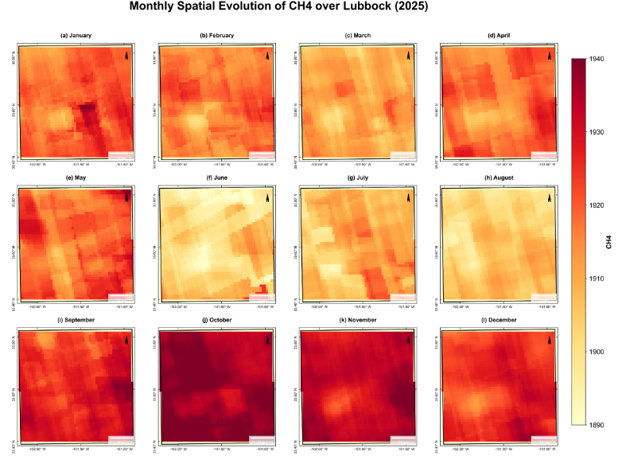

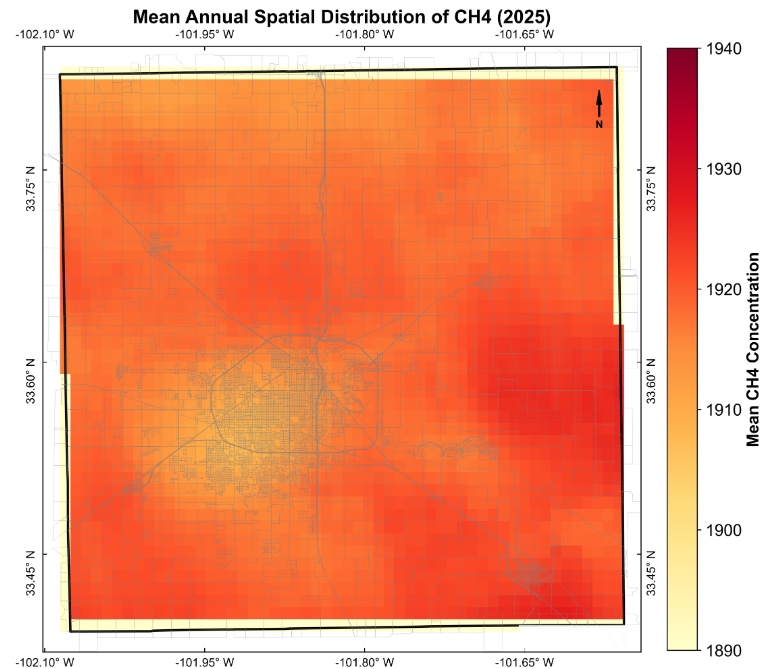

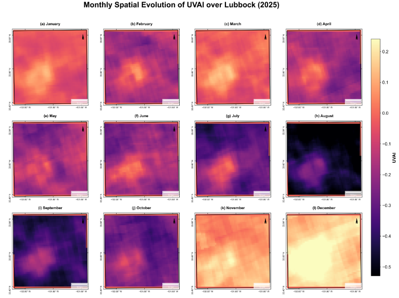

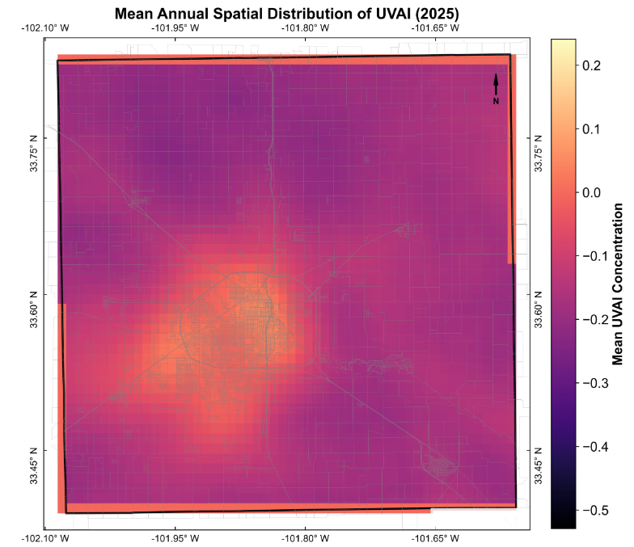

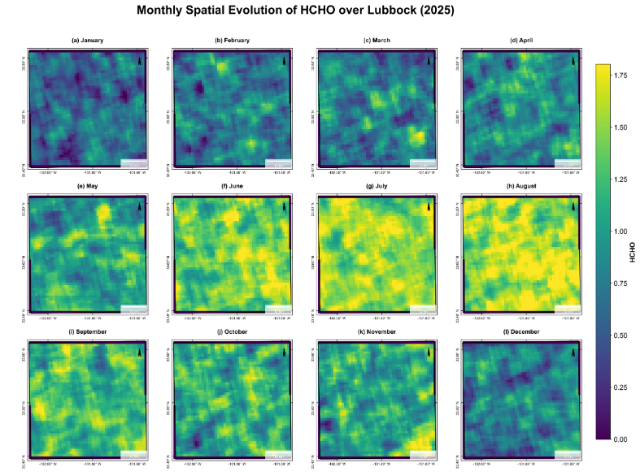

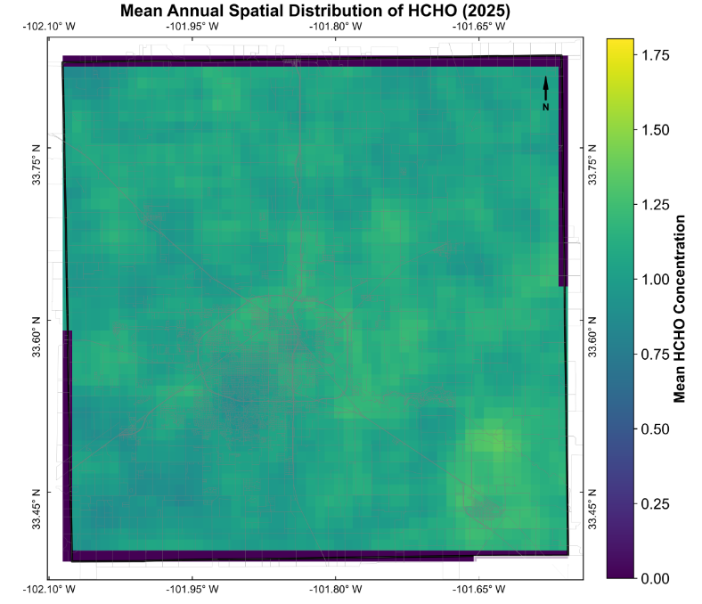

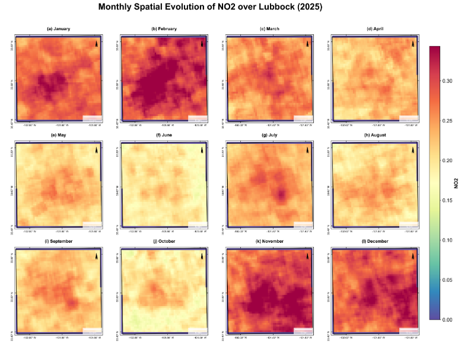

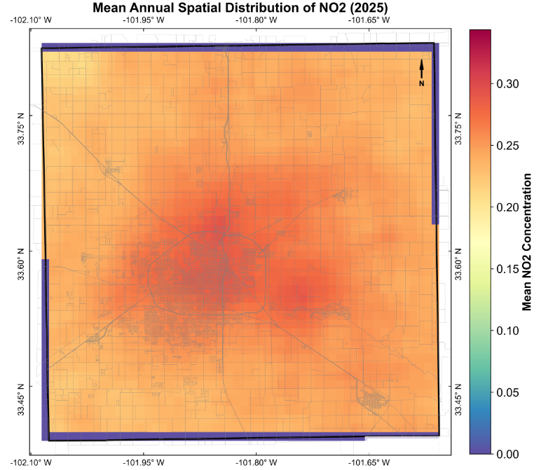

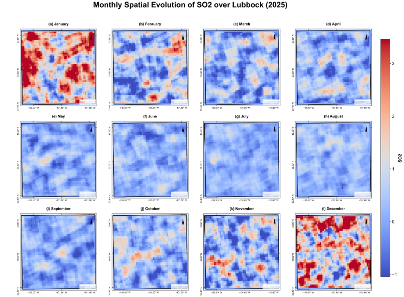

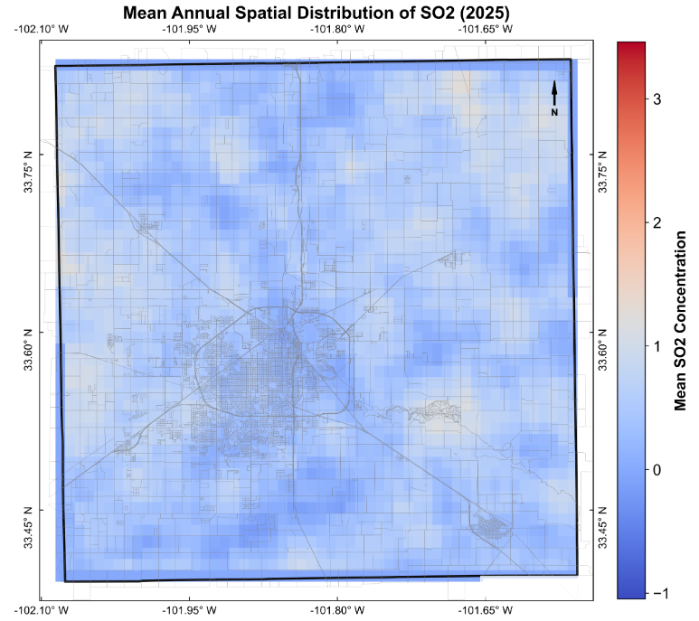

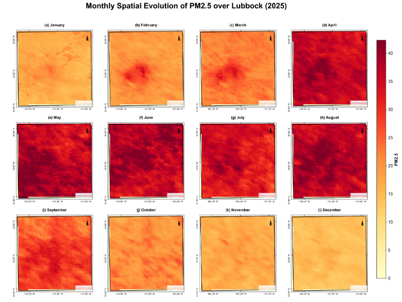

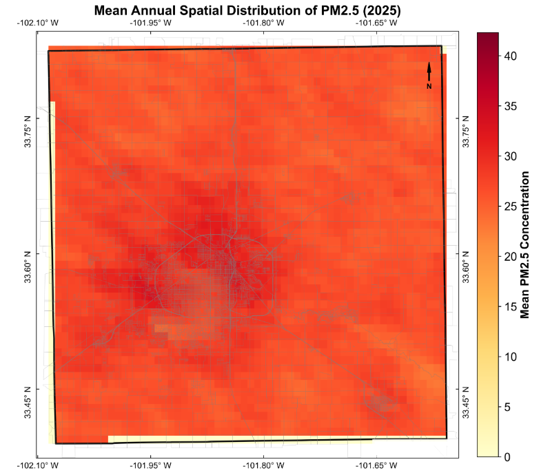

[2 more figures not shown]

```python
# 6. CORRELATION SCATTERPLOTS (DAILY RESOLUTION)
# ------------------------------------------------------------------------------
print("⌛ Generating Correlation Scatterplots...")
fig, axes = plt.subplots(3, 3, figsize=(15, 15))
axes = axes.flatten()

for i, var in enumerate(plot_vars):
    ax = axes[i]
    var_label = 'PM2.5' if var == 'PM25' else var
    sns.regplot(data=df_daily, x='LST_Day', y=var, ax=ax, scatter_kws={'alpha':0.4, 'color':'#2c3e50', 's':15}, line_kws={'color':'red', 'lw':2.5})

    mask = ~np.isnan(df_daily['LST_Day']) & ~np.isnan(df_daily[var])
    if mask.sum() > 2:
        _, _, r_val, _, _ = stats.linregress(df_daily['LST_Day'][mask], df_daily[var][mask])
        ax.set_title(f'LST Day vs {var_label} ($R^2$ = {r_val**2:.2f})', weight='bold')
    ax.grid(linestyle=':', alpha=0.6)

# Hide remaining empty subplots
for j in range(len(plot_vars), len(axes)):
    axes[j].axis('off')

plt.tight_layout()
plt.savefig(os.path.join(OUTPUT_DIR, 'Graph_Correlation_Scatterplots.png'))
plt.show()
```

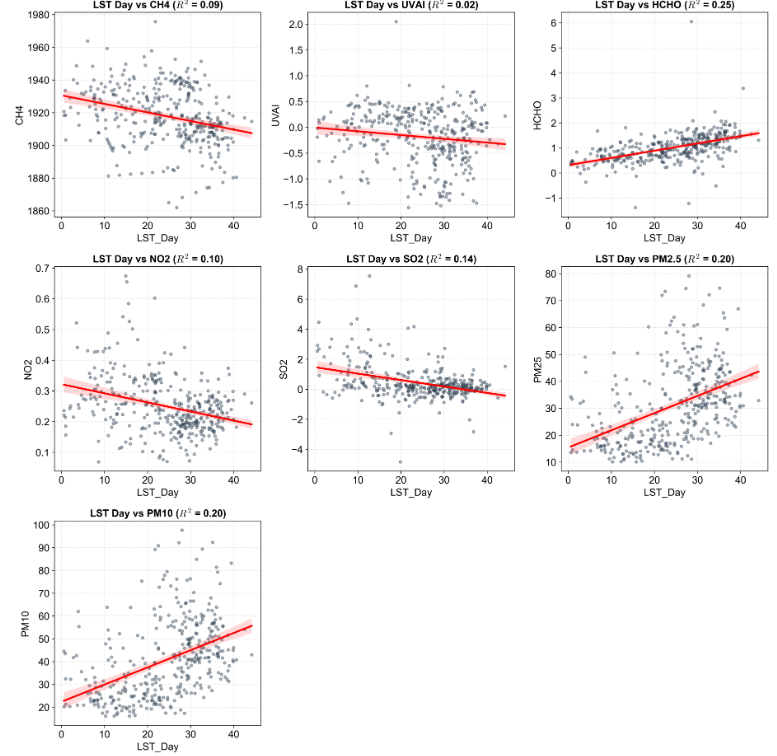

```python
# 7. MULTIVARIATE DIAGNOSTICS: PEARSON & PCA
# Reference: Sameh et al. (2026); Jolliffe (2002)
# ------------------------------------------------------------------------------
print("⌛ Computing Principal Component Analysis and Correlation Matrix...")
pca_features = df_daily[['CH4', 'UVAI', 'HCHO', 'NO2', 'SO2', 'LST_Day']].dropna()
pca_features = pca_features.rename(columns={'LST_Day': 'LST Day'})
corr_matrix = pca_features.corr()

scaler = StandardScaler()
X_scaled = scaler.fit_transform(pca_features)
pca = PCA()
pca.fit(X_scaled)
cum_var = np.cumsum(pca.explained_variance_ratio_)

fig, axes = plt.subplots(1, 2, figsize=(18, 8))
sns.heatmap(corr_matrix, ax=axes[0], mask=np.triu(np.ones_like(corr_matrix, dtype=bool)),
            cmap='coolwarm', vmin=-1, vmax=1, annot=True, fmt=".2f", annot_kws={"size": 11})
axes[0].set_title('(a) Pearson Correlation Matrix', weight='bold')

axes[1].plot(range(1, len(cum_var)+1), cum_var, marker='o', color='navy', lw=2.5)
axes[1].axhline(0.95, color='red', linestyle='--', lw=2, label='95% Variance')
axes[1].set_xlabel('Principal Component', weight='bold')
axes[1].set_ylabel('Cumulative Variance', weight='bold')
axes[1].set_title('(b) PCA Scree Plot', weight='bold')
axes[1].grid(True, linestyle=':')
axes[1].legend()

plt.tight_layout()
plt.savefig(os.path.join(OUTPUT_DIR, 'Fig2_Multivariate_Diagnostics.png'))
plt.show()
```

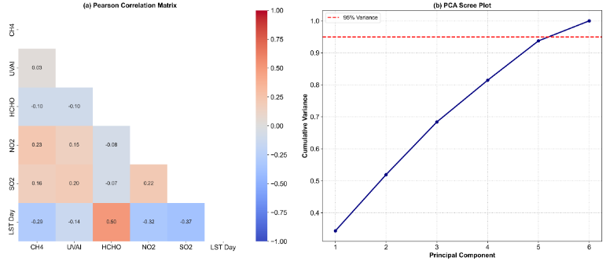

```python
# 8. SPATIAL NON-STATIONARITY: GWR CONTINUOUS ZONAL MAP
# Reference: Sameh et al. (2026); Fotheringham et al. (2002)
# ------------------------------------------------------------------------------
print("⌛ Executing Geographically Weighted Regression (Continuous Surface)...")

def create_gwr_continuous_surface(target='CH4', predictor='LST_Day'):
    """Generates continuous local R2 map via spatial interpolation of GWR weights."""
    pts = ee.FeatureCollection.randomPoints(roi, points=400, seed=42)
    lst_img = lst_col.mean().select('LST_Day_1km').multiply(0.02).subtract(273.15).rename('LST_Day')

    if target in datasets_meta:
        target_img = ee.ImageCollection(datasets_meta[target]['col']).filterBounds(roi).filterDate(START_DATE, END_DATE).select(datasets_meta[target]['band']).mean().multiply(datasets_meta[target]['scale']).rename(target)
    elif target == 'PM25':
        target_img = get_pm_models(aod_col.filterDate(START_DATE, END_DATE).mean()).select('PM25').rename(target)

    combined = lst_img.addBands(target_img)
    sampled = combined.sampleRegions(collection=pts, scale=2000, geometries=True).getInfo()

    df_pts = pd.DataFrame([f['properties'] for f in sampled['features']])
    df_pts['lon'] = [f['geometry']['coordinates'][0] for f in sampled['features']]
    df_pts['lat'] = [f['geometry']['coordinates'][1] for f in sampled['features']]
    df_pts = df_pts.dropna()

    local_r2 = []
    y, x = df_pts[target].values, df_pts[predictor].values
    n = len(df_pts)

    for i in range(n):
        dist = np.sqrt((df_pts['lon'].values - df_pts['lon'].iloc[i])**2 + (df_pts['lat'].values - df_pts['lat'].iloc[i])**2)
        weights = np.exp(- (dist / 0.1)**2) # 0.1 degree bandwidth

        X_mat = np.vstack([np.ones(n), x]).T
        W_diag = np.diag(weights)
        try:
            beta = np.linalg.solve(X_mat.T @ W_diag @ X_mat, X_mat.T @ W_diag @ y)
            y_pred = X_mat @ beta
            ss_tot = np.sum(weights * (y - np.average(y, weights=weights))**2)
            ss_res = np.sum(weights * (y - y_pred)**2)
            r2 = max(0.0, 1.0 - (ss_res / ss_tot)) if ss_tot > 0 else 0.0
        except np.linalg.LinAlgError:
            r2 = np.nan
        local_r2.append(r2)

    df_pts['Local_R2'] = local_r2
    df_pts = df_pts.dropna()

    grid_x, grid_y = np.mgrid[lon_min:lon_max:500j, lat_min:lat_max:500j]
    grid_z = griddata((df_pts['lon'], df_pts['lat']), df_pts['Local_R2'], (grid_x, grid_y), method='cubic')

    fig, ax = plt.subplots(figsize=(10, 10))
    im = ax.imshow(grid_z.T, extent=(lon_min, lon_max, lat_min, lat_max), origin='lower', cmap='YlOrRd', vmin=0, vmax=1)
    roi_gdf.boundary.plot(ax=ax, color='black', linewidth=2.0)

    blocks_gdf.boundary.plot(ax=ax, edgecolor='gray', linewidth=0.3, alpha=0.4)
    var_label = 'PM2.5' if target == 'PM25' else target
    apply_custom_map_style(ax, roi_gdf, f"Continuous GWR Local R² ({predictor} vs {var_label})", is_factor_grid=False)
    cbar = plt.colorbar(im, ax=ax, fraction=0.046, pad=0.04)
    cbar.set_label('Local R² Explanatory Power', weight='bold', fontsize=14)
    plt.savefig(os.path.join(OUTPUT_DIR, f'Map_GWR_Continuous_{target}.png'))
    plt.show()

create_gwr_continuous_surface('CH4')
create_gwr_continuous_surface('PM25')
```

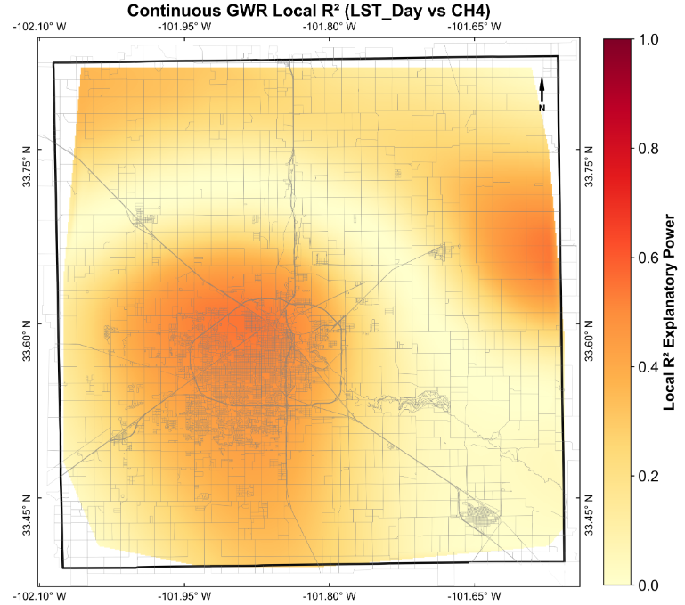

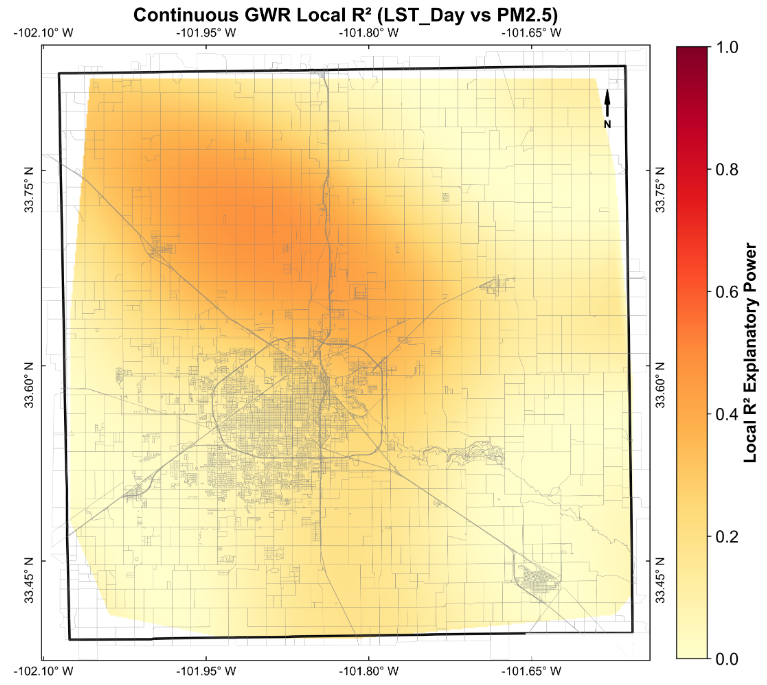